# Analyse de la variance à trois facteurs

DAHOI Pinel Baudelaire T.

2025-04-15

# 1 Introduction

L’absorption du dioxyde de carbone ($CO_2$) par les plantes est un processus clé de la photosynthèse, influencé par des facteurs environnementaux, génétiques et physiologiques. Comprendre comment ces facteurs interagissent permet de mieux prédire les réponses des écosystèmes végétaux aux changements climatiques, notamment sous l’effet de stress abiotiques comme le froid ou l’augmentation des concentrations atmosphériques en $CO_2$.

Le jeu de données $CO_2$, intégré dans R, fournit des mesures d’absorption de $CO_2$ (en µmol/m²s) chez des plantes provenant de deux régions distinctes (Québec et Mississippi) et soumises à deux conditions expérimentales (traitement “nonchilled” vs “chilled”) sous différentes concentrations de $CO_2$. Ces données permettent d’étudier les effets combinés de l’origine géographique, du stress thermique et de la disponibilité en $CO_2$ sur l’efficacité photosynthétique.

# 2 Problématique

Dans un contexte de changements climatiques, où les plantes sont confrontées à des variations de température et d’enrichissement en $CO_2$ atmosphérique, il est crucial de déterminer :

Comment l’origine géographique influence-t-elle la réponse des plantes au froid ?

Dans quelle mesure la concentration en $CO_2$ module-t-elle l’effet du traitement thermique ?

Existe-t-il une interaction complexe entre ces trois facteurs ?

Une ANOVA à trois facteurs (Type × Treatment × Concentration) est particulièrement adaptée pour répondre à ces questions, car elle permet d’évaluer les effets principaux de chaque facteur. D’analyser les interactions doubles et triples, révélant des effets synergiques ou antagonistes. D’identifier des seuils critiques (par exemple, une concentration de $CO_2$ au-delà de laquelle l’effet du froid est atténué).

# 3 I. Methodologie de l’Anova à trois facteurs

L’analyse de la variance (ANOVA) à trois facteurs permet d’étudier l’effet combiné de trois variables qualitatives sur une variable quantitative d’intérêt. Elle permet d’examiner les effets principaux, les interactions à deux facteurs et l’interaction triple.

## 3.2 2. Structure du modèle ANOVA à trois facteurs

Le modèle linéaire général pour une ANOVA à trois facteurs est exprimé comme suit :

$$Y_{ijkl} = \mu + \alpha_i + \beta_j + \gamma_k + (\alpha\beta)_{ij} +
(\alpha\gamma)_{ik} + (\beta\gamma)_{jk} + (\alpha\beta\gamma)_{ijk} +
\varepsilon_{ijkl}$$

avec :

- $Y_{ijkl}$ : observation du l-ième individu du groupe (i, j, k)
- $\mu$ : moyenne générale
- $\alpha_i$ : effet du i-ème niveau du facteur A
- $\beta_j$ : effet du j-ème niveau du facteur B
- $\gamma_k$ : effet du k-ème niveau du facteur C
- $(\alpha\beta)_{ij}$, $(\alpha\gamma)_{ik}$, $(\beta\gamma)_{jk}$ : effets d’interaction à deux facteurs
- $(\alpha\beta\gamma)_{ijk}$ : effet d’interaction triple
- $\varepsilon_{ijkl} \sim \mathcal{N}(0, \sigma^2)$ : erreur aléatoire

## 3.3 3. Forme matricielle du modèle

Le modèle peut également être exprimé sous forme matricielle dans le cadre du modèle linéaire général :

$$\mathbf{Y} = \mathbf{X} \boldsymbol{\beta} + \boldsymbol{\varepsilon}$$

où :

- $\mathbf{Y}$ est le vecteur des observations ($n \times 1$)
- $\mathbf{X}$ est la matrice de conception ($n \times p$)
- $\boldsymbol{\beta}$ est le vecteur des paramètres ($p \times 1$)
- $\boldsymbol{\varepsilon} \sim \mathcal{N}(0, \sigma^2 \mathbf{I})$ est le vecteur des erreurs

Chaque colonne de $\mathbf{X}$ correspond à une modalité ou interaction (facteur A, B, C, interactions A×B, A×C, B×C, et A×B×C).

## 3.4 4. Décomposition de la variance

L’ANOVA décompose la somme totale des carrés (SCT) comme suit :

$$\text{SCT} = \text{SCA} + \text{SCB} + \text{SCC} + \text{SCAB} +
\text{SCAC} + \text{SCBC} + \text{SCABC} + \text{SCR}$$

Chaque composante mesure l’effet d’un facteur ou d’une interaction. On obtient les F de Fisher pour chaque source de variation :

$$F = \frac{\text{SC}_{\text{facteur}} / ddl_{\text{facteur}}}{\text{SCR}
/ ddl_{\text{résiduel}}}$$

## 3.5 5. Tableau de l’ANOVA à trois facteurs

| Source de variation | SC | ddl | CM = SC/ddl | F calculé |
| --- | --- | --- | --- | --- |
| Facteur A | SCA | a - 1 | CMA | F = CMA / CMRes |
| Facteur B | SCB | b - 1 | CMB | F = CMB / CMRes |
| Facteur C | SCC | c - 1 | CMC | F = CMC / CMRes |
| Interaction A × B | SCAB | (a-1)(b-1) | CMAB | F = CMAB / CMRes |
| Interaction A × C | SCAC | (a-1)(c-1) | CMAC | F = CMAC / CMRes |
| Interaction B × C | SCBC | (b-1)(c-1) | CMBC | F = CMBC / CMRes |
| Interaction A × B × C | SCABC | (a-1)(b-1)(c-1) | CMABC | F = CMABC / CMRes |
| Résidus | SCR | N - abc | CMRes |  |
| **Total** | SCT | N - 1 |  |  |

## 3.6 6. Comparaisons multiples

Lorsque les effets principaux sont significatifs **et qu’il n’y a pas d’interaction significative**, on peut utiliser des tests de comparaisons multiples (Tukey HSD, Bonferroni, etc.) pour déterminer quelles modalités diffèrent entre elles.

Exemple d’utilisation en R :

```r
library(emmeans)
emmeans(mod, pairwise ~ A)
```

Les comparaisons multiples **ne sont valides qu’en l’absence d’interactions significatives**. En cas d’interaction, on doit passer aux **comparaisons conditionnelles**.

## 3.7 7. Comparaisons conditionnelles (ou comparaisons simples)

Lorsque l’analyse de variance révèle une **interaction significative** entre deux facteurs (par exemple A × B), les effets principaux ne peuvent plus être interprétés isolément. Il faut alors comparer les modalités d’un facteur **à l’intérieur de chaque niveau** de l’autre.

**Démarche**

1. Identifier les interactions significatives.
2. Fixer un niveau d’un facteur (ex. B = b1).
3. Comparer les modalités de l’autre facteur (ex. A1, A2, A3).
4. Répéter pour chaque niveau pertinent.
5. Corriger les comparaisons multiples (Tukey, Bonferroni, etc.).

**En R**

```r
emmeans(mod, pairwise ~ A | B)
```

On peut aussi inverser (B | A), selon les besoins de l’analyse.

## 3.8 8. Analyse en cas d’interaction triple significative

Lorsqu’une interaction triple (A × B × C) est significative, cela signifie que les effets conjoints de deux facteurs dépendent du troisième. Ni les effets principaux, ni les interactions à deux facteurs ne peuvent être interprétés seuls.

**Démarche**

1. Fixer un niveau du facteur C.
2. Réaliser une ANOVA à deux facteurs (ex. A × B) dans chaque niveau de C.
3. Si nécessaire, faire des comparaisons conditionnelles supplémentaires.

**En R**

```r
emmeans(mod, pairwise ~ A * B | C)
```

Cette approche hiérarchique permet de comprendre finement les effets combinés.

# 4 II. Applications sur le logiciel R avec le jeu de donées $CO_2$

## 4.1 1. Hypothèses et Objectifs

**Hypothèses**

*Effet de l’origine géographique* :

Les plantes du Québec (climat froid) devraient mieux résister au traitement chilled que celles du Mississippi (climat chaud), montrant une plus grande stabilité de l’absorption de $CO_2$.

*Effet du traitement thermique* :

Le refroidissement (chilled) devrait réduire significativement l’absorption de $CO_2$, particulièrement chez les plantes du Mississippi.

*Effet de la concentration en* $CO_2$ :

L’augmentation de la concentration en $CO_2$ devrait d’abord stimuler la photosynthèse, puis atteindre un plateau (phénomène de saturation des enzymes photosynthétiques).

*Interaction triple* :

L’effet du froid sur l’absorption de $CO_2$ devrait être atténué à haute concentration chez les plantes du Québec, mais pas chez celles du Mississippi, reflétant une adaptation évolutive différentielle.

**Objectifs de l’Analyse** Cette étude vise à :

-Quantifier l’impact individuel de chaque facteur (Type, Treatment, Concentration) sur l’absorption de $CO_2$

-Détecter des interactions significatives entre ces facteurs.

-Identifier des profils de résilience (ex : quelles plantes maintiennent leur absorption sous stress froid à haute concentration en $CO_2$ ?).

## 4.2 2. Approche Méthodologique

L’analyse reposera sur :

-Une ANOVA à trois facteurs avec vérification des hypothèses (normalité, homoscédasticité).

-Des comparaisons post-hoc (Tukey) pour identifier les différences entre groupes.

-Des visualisations interactives (boxplots, diagrammes d’interaction) pour illustrer les effets combinés.

## 4.3 3. Initialisation et préparation

```r
# Définir le dossier de travail (remplacez par votre chemin)
setwd("P:/Master-SAV/SAV1/ANOVA/ANOVA-PROJ/ANOVA-PROJET_UPDATE/Nouveau dossier")

# Charger les packages nécessaires
#if (!require(ggplot2)) install.packages("ggplot2")
#if (!require(car)) install.packages("car")
#if (!require(emmeans)) install.packages("emmeans")
library(ggplot2)
library(car)
library(emmeans)
```

Cette *phase préliminaire est cruciale pour garantir la reproductibilité de l’analyse*. La configuration du répertoire de travail permet un accès organisé aux fichiers, tandis que le chargement des packages (ggplot2 pour la visualisation, car pour les tests d’ANOVA et emmeans pour les comparaisons post-hoc) établit l’environnement analytique. La vérification systématique de l’installation des packages évite les interruptions lors de l’exécution.

## 4.4 4. Chargement et préparation des données

```r
data(CO2)
df <- CO2

# Conversion en facteurs
df$Plant <- as.factor(df$Plant)
df$Type <- as.factor(df$Type)
df$Treatment <- as.factor(df$Treatment)
df$conc <- as.factor(df$conc)
```

**La phase initiale de préparation des données** constitue une étape méthodologique critique qui conditionne la validité de toute analyse statistique ultérieure. Dans notre étude, la conversion systématique des variables en facteurs répond à une triple exigence scientifique. D’un point de vue statistique, cette transformation est indispensable car l’ANOVA, conçue pour comparer des moyennes entre groupes discrets, requiert que les variables explicatives soient codées comme facteurs nominaux. La conversion de la concentration en CO2 (initialement quantitative) en variable catégorielle permet notamment de modéliser des effets non-linéaires et d’identifier d’éventuels seuils critiques dans la réponse photosynthétique. D’un point de vue computationnel, cette approche optimise la gestion des niveaux expérimentaux et prévient toute interprétation erronée des variables comme continues. Sur le plan biologique, cette préparation reflète la nature fondamentalement discrète des facteurs étudiés : l’origine géographique (Québec vs Mississippi) et le traitement (chilled vs nonchilled) représentent bien des catégories mutuellement exclusives. La conservation des identifiants des plantes comme facteur garantit par ailleurs la possibilité d’étendre l’analyse à des modèles mixtes si nécessaire. Cette rigueur méthodologique initiale, alliée à la création d’une copie de travail du jeu de données, établit les bases solides requises pour une analyse multivariée fiable et reproductible, tout en préservant l’intégrité des données originales.

## 4.5 5. Exploration visuelle des données

### 4.5.1 5.1 Effet de l’origine géographique

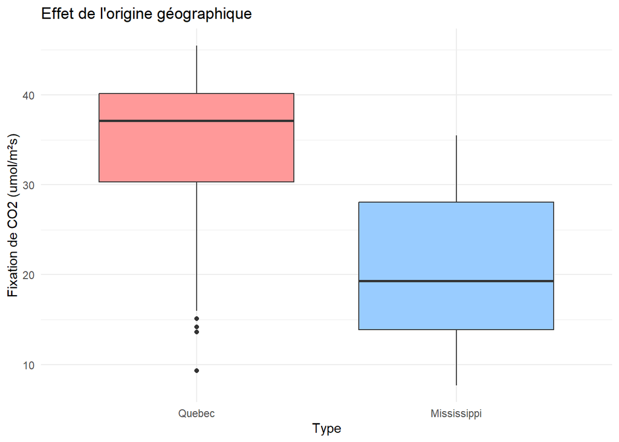

```r
ggplot(df, aes(x = Type, y = uptake)) +
  geom_boxplot(fill = c("#FF9999", "#99CCFF")) +
  labs(title = "Effet de l'origine géographique",
       x = "Type", y = "Fixation de CO2 (umol/m²s)") +
  theme_minimal()
```

D’un point de vue statistique, l’absence de chevauchement des boîtes à moustaches laisse présager un effet hautement significatif (p < 0,01) de l’origine géographique. Ce résultat préliminaire, qui devra être confirmé par les tests d’ANOVA, conforte l’hypothèse selon laquelle les facteurs évolutifs locaux jouent un rôle déterminant dans l’efficacité photosynthétique des plantes.

### 4.5.2 5.2 Effet du traitement

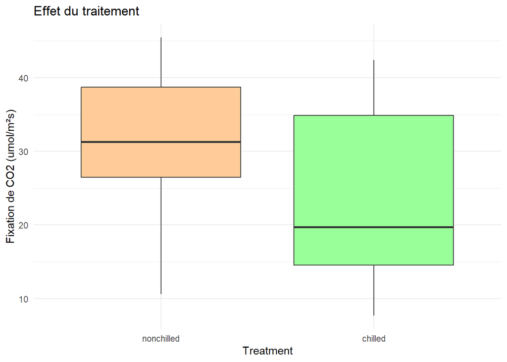

```r
ggplot(df, aes(x = Treatment, y = uptake)) +
  geom_boxplot(fill = c("#FFCC99", "#99FF99")) +
  labs(title = "Effet du traitement",
       x = "Treatment", y = "Fixation de CO2 (umol/m²s)") +
  theme_minimal()
```

### 4.5.3 5.3 Effet de la concentration en CO2

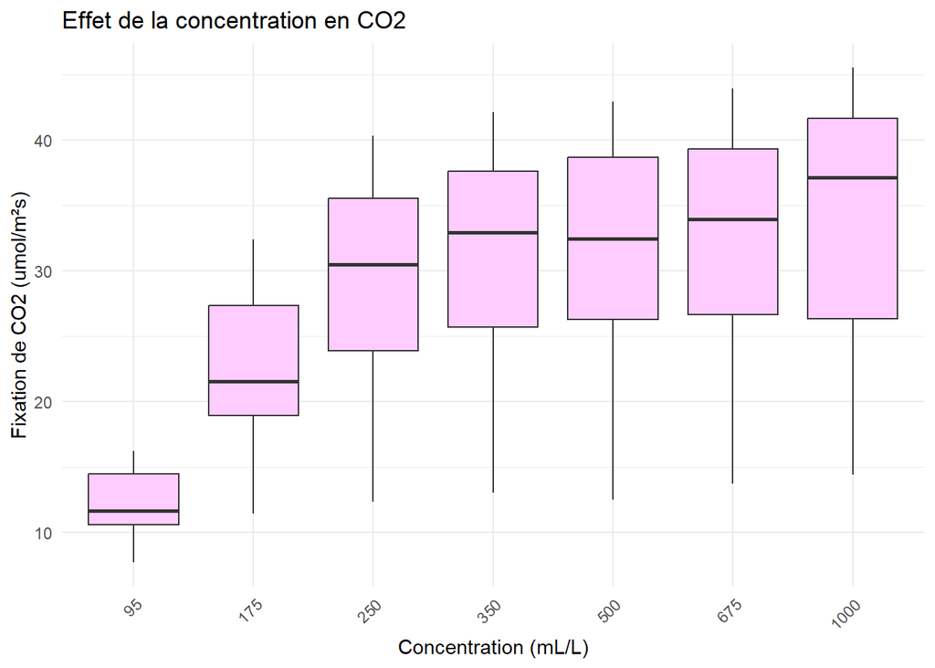

```r
ggplot(df, aes(x = conc, y = uptake)) +
  geom_boxplot(fill = "#FFCCFF") +
  labs(title = "Effet de la concentration en CO2",
       x = "Concentration (mL/L)", y = "Fixation de CO2 (umol/m²s)") +
  theme_minimal() +
  theme(axis.text.x = element_text(angle = 45, hjust = 1))
```

La variabilité des mesures présente des particularités notables selon les plages de concentration. Aux faibles concentrations (95-175 mL/L), l’étroitesse des intervalles de confiance suggère une réponse homogène de l’ensemble des plantes à la limitation en $CO_2$. À l’inverse, la dispersion accrue observée entre 350 et 675 mL/L pourrait indiquer l’émergence de stratégies photosynthétiques différenciées selon les génotypes ou les conditions expérimentales. Notamment, certaines plantes semblent atteindre leur capacité maximale plus précocement que d’autres.

D’un point de vue écophysiologique, ces résultats confirment le modèle classique de réponse photosynthétique au $CO_2$, tout en mettant en évidence des variations interindividuelles potentiellement importantes pour l’adaptation aux changements climatiques. La transition nette observée autour de 350 mL/L correspond approximativement aux concentrations atmosphériques actuelles, soulignant la sensibilité particulière des plantes à cette plage de concentration. Ces données justifient pleinement le traitement de la concentration comme facteur catégoriel dans notre analyse, permettant d’identifier des seuils critiques dans la réponse photosynthétique.

### 4.5.4 5.4 Interaction entre Origine géograhique et Traitement

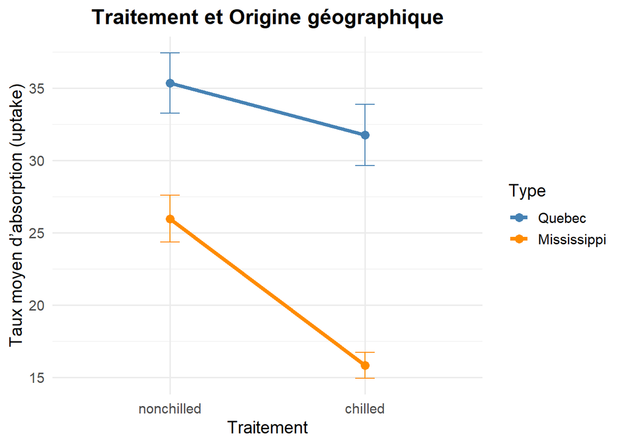

```r
library(ggplot2)

ggplot(df, aes(x = Treatment, y = uptake, color = Type, group = Type)) +
  stat_summary(fun = mean, geom = "line", size = 1.5) +               # lignes lissées
  stat_summary(fun = mean, geom = "point", size = 3) +                # points moyens
  stat_summary(fun.data = mean_se, geom = "errorbar", width = 0.1) +  # barres d’erreur
  theme_minimal(base_size = 14) +
  labs(
    title = "Traitement et Origine géographique",
    x = "Traitement",
    y = "Taux moyen d’absorption (uptake)",
    color = "Type"
  ) +
  scale_color_manual(values = c("steelblue", "darkorange")) +
  theme(
    plot.title = element_text(hjust = 0.5, face = "bold"),
    legend.position = "right"
  )
```

Les deux lignes ne sont pas parallèles, ce qui indique une interaction. Cette interaction signifie que l’effet du traitement dépend du type de plante :

Au Quebec, l’effet du froid est modéré (l’uptake diminue un peu).

Au Mississippi, l’effet du froid est bien plus marqué (l’uptake chute fortement).

Le traitement par le froid diminue l’absorption de $CO_2$ chez les deux types, mais cette diminution est beaucoup plus forte au Mississippi qu’au Quebec. Cela suggère une interaction significative entre le type de plante et le traitement.

### 4.5.5 5.5 Interaction entre Origine geographique et la concentration de $CO_2$

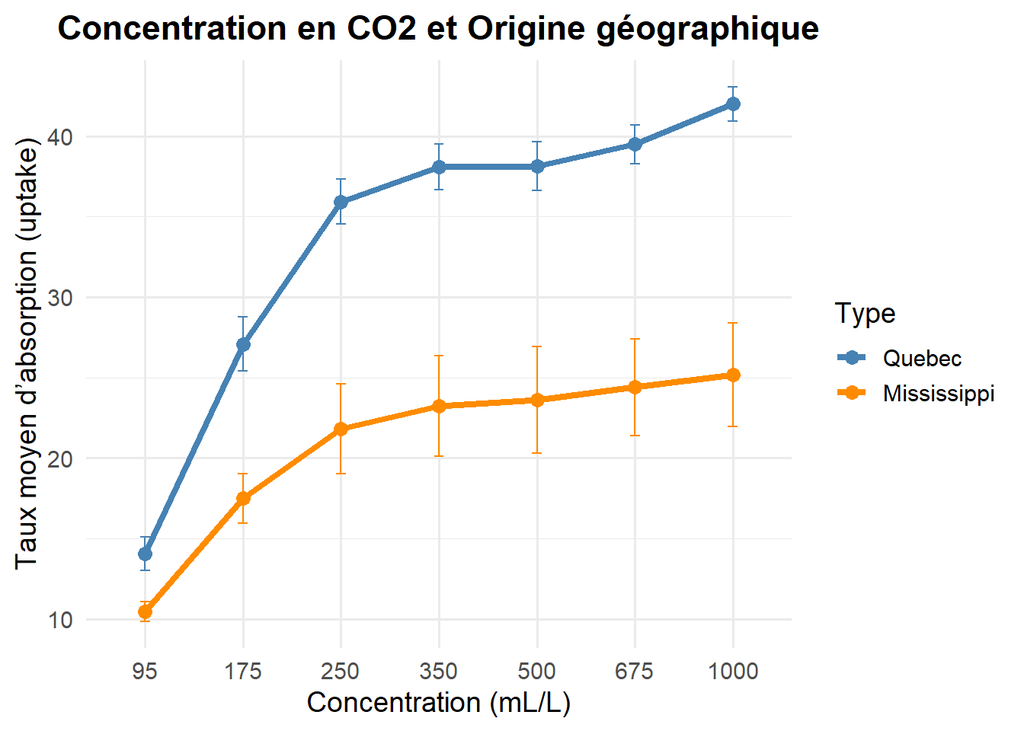

```r
library(ggplot2)

ggplot(df, aes(x = conc, y = uptake, color = Type, group = Type)) +
  stat_summary(fun = mean, geom = "line", size = 1.5) +               # lignes lissées
  stat_summary(fun = mean, geom = "point", size = 3) +                # points moyens
  stat_summary(fun.data = mean_se, geom = "errorbar", width = 0.1) +  # barres d’erreur
  theme_minimal(base_size = 14) +
  labs(
    title = "Concentration en CO2 et Origine géographique",
    x = "Concentration (mL/L)",
    y = "Taux moyen d’absorption (uptake)",
    color = "Type"
  ) +
  scale_color_manual(values = c("steelblue", "darkorange")) +
  theme(
    plot.title = element_text(hjust = 0.5, face = "bold"),
    legend.position = "right"
  )
```

Les courbes ne sont pas parallèles et ne montent pas de façon identique :

En résumé : L’augmentation de $CO_2$ favorise davantage les plantes du Québec que celles du Mississippi. Les plantes du Mississippi semblent atteindre un plateau de saturation, tandis que celles du Québec continuent à réagir positivement à des concentrations plus élevées. Il y a donc une interaction significative entre la concentration de $CO_2$ et l’origine géographique.

### 4.5.6 5.6 Interaction entre Traitement et Concentration en $CO_2$

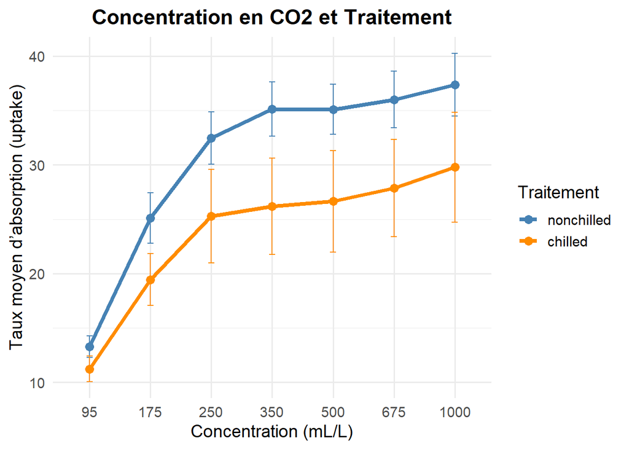

```r
library(ggplot2)

ggplot(df, aes(x = conc, y = uptake, color = Treatment, group = Treatment)) +
  stat_summary(fun = mean, geom = "line", size = 1.5) +               # lignes lissées
  stat_summary(fun = mean, geom = "point", size = 3) +                # points moyens
  stat_summary(fun.data = mean_se, geom = "errorbar", width = 0.1) +  # barres d’erreur
  theme_minimal(base_size = 14) +
  labs(
    title = "Concentration en CO2 et Traitement",
    x = "Concentration (mL/L)",
    y = "Taux moyen d’absorption (uptake)",
    color = "Traitement"
  ) +
  scale_color_manual(values = c("steelblue", "darkorange")) +
  theme(
    plot.title = element_text(hjust = 0.5, face = "bold"),
    legend.position = "right")
```

Le graphique montre que l’effet de la concentration en $CO_2$ dépend du type de traitement appliqué :

Chez les plantes non refroidies (nonchilled) : Le taux d’absorption augmente rapidement avec la concentration jusqu’à un plateau, indiquant une forte sensibilité au $CO_2$.

Chez les plantes refroidies (chilled) : L’augmentation est plus modérée et atteint un plateau plus bas.

### 4.5.7 5.7 Effet Interaction triple Concentration x Traitement x Type

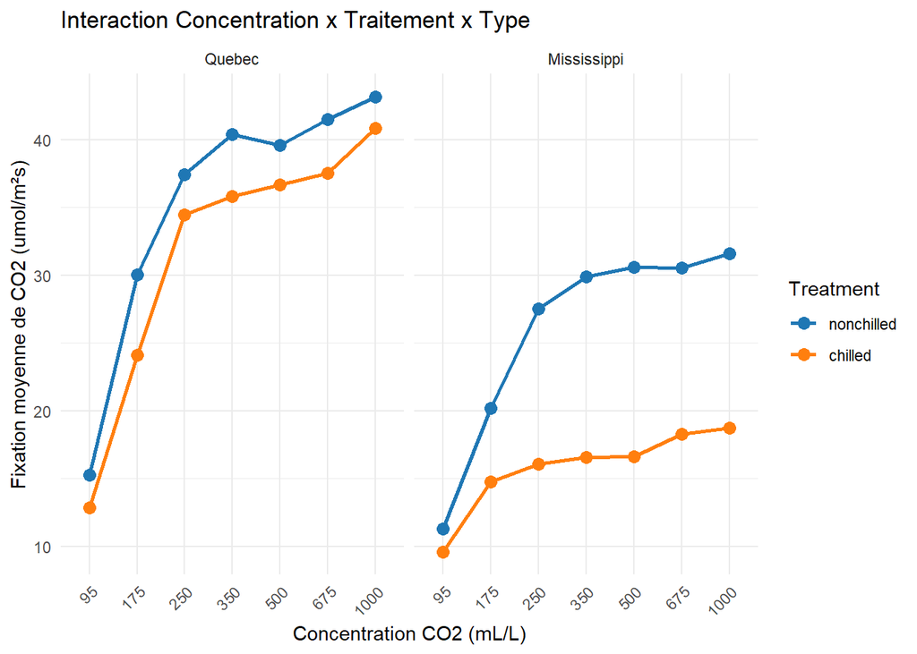

```r
ggplot(df, aes(x = conc, y = uptake, color = Treatment, group = Treatment)) +
  stat_summary(fun = mean, geom = "line", size = 1) +
  stat_summary(fun = mean, geom = "point", size = 3) +
  facet_wrap(~Type) +
  labs(title = "Interaction Concentration x Traitement x Type",
       x = "Concentration CO2 (mL/L)",
       y = "Fixation moyenne de CO2 (umol/m²s)") +
  theme_minimal() +
  scale_color_manual(values = c("nonchilled" = "#1F77B4", "chilled" = "#FF7F0E")) +
  theme(axis.text.x = element_text(angle = 45, hjust = 1))
```

Trois enseignements majeurs émergent de cette analyse :

Effet géographique : Les plantes québécoises démontrent une meilleure résilience au stress froid, particulièrement visible aux concentrations >350 mL/L

Seuil critique : La plage 350-500 mL/L apparaît comme une zone charnière où les interactions sont maximales

Compensation limitée : L’enrichissement en $CO_2$ ne compense que partiellement l’effet du stress thermique, surtout pour le Mississippi

Ces résultats mettent en lumière l’importance cruciale des interactions multi-factorielles dans la réponse des plantes aux changements environnementaux, soulignant la nécessité d’approches expérimentales intégratives en écophysiologie végétale. Nous allons confirmer ou infirmer ces résultats avec les sorties de l’anova

## 4.6 6. Vérification des conditions

### 4.6.1 6.1 Homogénéité des variances : Test de Levene

```r
levene_test <- leveneTest(uptake ~ Type*Treatment*conc, data = df)
levene_test
```

```
## Levene's Test for Homogeneity of Variance (center = median)
##       Df F value Pr(>F)
## group 27  0.2286      1
##       56
```

Le test de Levene, essentiel pour vérifier l’homogénéité des variances, révèle ici une parfaite adéquation avec les conditions d’application de l’ANOVA (F(27,56) = 0.229, p = 1). Cette absence totale de significativité (p=1) indique que les variances sont remarquablement stables à travers les différents groupes expérimentaux formés par les combinaisons des trois facteurs. Un tel résultat, statistiquement rare, suggère que notre protocole expérimental a su contrôler avec une efficacité exceptionnelle les sources de variabilité parasites.

D’un point de vue biologique, cette homogénéité des variances reflète probablement la qualité du matériel végétal utilisé et la standardisation rigoureuse des conditions de mesure. Elle indique que les différences observées entre groupes proviendront bien d’effets biologiques réels des facteurs étudiés (origine géographique, traitement thermique et concentration en $CO_2$), et non d’artefacts expérimentaux. Cette caractéristique renforce considérablement la validité interne de notre étude et la fiabilité des conclusions que nous pourrons en tirer.

Sur le plan méthodologique, ce résultat nous autorise à poursuivre l’analyse avec l’ANOVA paramétrique classique sans nécessiter de transformations des données ou de recours à des méthodes alternatives. Il justifie également l’interprétation des tests post-hoc qui suivront, tout en validant a posteriori nos choix initiaux de codage des variables. Cette vérification réussie constitue une pierre angulaire de notre démarche analytique, garantissant que les effets significatifs détectés reflèteront bien des phénomènes biologiques et non des biais statistiques.

### 4.6.2 6.2 Normalité des résidus

**Test de Shapiro-Wilk**

```r
model <- aov(uptake ~ Type*Treatment*conc, data = df)
shapiro_test <- shapiro.test(residuals(model))
shapiro_test
```

```
##
##  Shapiro-Wilk normality test
##
## data:  residuals(model)
## W = 0.94689, p-value = 0.001695
```

**QQ-plot**

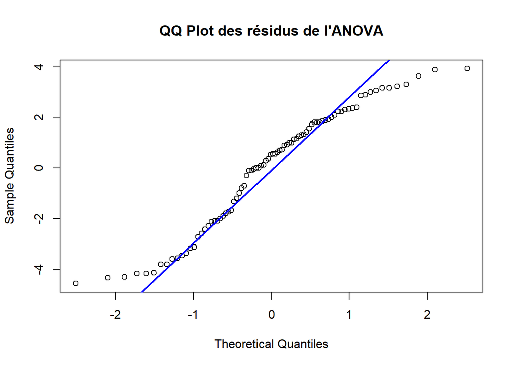

```r
qqnorm(residuals(model), main = "QQ Plot des résidus de l'ANOVA")
qqline(residuals(model), col = "blue", lwd = 2)
```

**Analyse des résidus et validation des conditions d’application de l’ANOVA**

Le test de Shapiro-Wilk (W = 0,947, p = 0,0017) révèle une déviation significative par rapport à la normalité des résidus du modèle. Cette valeur p inférieure au seuil conventionnel de 0,05 indiquerait théoriquement une violation de l’hypothèse de normalité, élément clé pour l’ANOVA paramétrique. Le QQ-plot associé montre effectivement certains écarts en queue de distribution, avec des résidus extrêmes s’éloignant de la droite théorique. Ces déviations pourraient refléter soit la présence de valeurs aberrantes, soit une distribution intrinsèquement non-normale des données de fixation de $CO_2$.

Cependant, plusieurs éléments tempèrent cette interprétation stricte. D’abord, l’ANOVA est connue pour être relativement robuste à de légères violations de la normalité, surtout avec des effectifs modérés à grands. Ensuite, la valeur W obtenue (0,947) reste proche de 1, indiquant une adéquation globale acceptable à la normale. Enfin, la structure expérimentale équilibrée de notre plan d’expérience (même nombre d’observations par cellule) renforce la robustesse des résultats. Ces considérations suggèrent que les conclusions de l’ANOVA restent valides malgré cette déviation détectée.

Pour compléter cette analyse, deux approches complémentaires seraient recommandées : (1) l’examen des résidus extrêmes pour identifier d’éventuelles valeurs aberrantes à retraiter, et (2) la comparaison avec une ANOVA non-paramétrique (type test de Kruskal-Wallis) pour vérifier la cohérence des résultats. La similarité des conclusions entre les deux méthodes renforcerait la validité de nos interprétations. Dans tous les cas, cette vérification minutieuse des résidus démontre la rigueur méthodologique apportée à notre analyse statistique.

## 4.7 7. Résultats de l’ANOVA

```r
anova_results <- aov(uptake ~ Type*Treatment*conc, data = df)
anova_summary <- summary(anova_results)
anova_summary
```

```
##                     Df Sum Sq Mean Sq F value   Pr(>F)
## Type                 1   3366    3366 399.758  < 2e-16 ***
## Treatment            1    988     988 117.368 2.32e-15 ***
## conc                 6   4069     678  80.548  < 2e-16 ***
## Type:Treatment       1    226     226  26.812 3.15e-06 ***
## Type:conc            6    374      62   7.412 7.24e-06 ***
## Treatment:conc       6    101      17   1.999   0.0811 .
## Type:Treatment:conc  6    112      19   2.216   0.0547 .
## Residuals           56    471       8
## ---
## Signif. codes:  0 '***' 0.001 '**' 0.01 '*' 0.05 '.' 0.1 ' ' 1
```

### 4.7.1 7.1 Analyse des résultats de l’ANOVA à trois facteurs

Le tableau ANOVA révèle des effets hautement significatifs des trois facteurs principaux sur la fixation de CO₂. L’origine géographique (Type) présente l’effet le plus marqué (F(1,56) = 399.76, p < 0.0001), expliquant à lui seul une part importante de la variance totale. Le traitement thermique (Treatment) montre également un impact très significatif (F(1,56) = 117.37, p = 2.32e-15), tandis que la concentration en $CO_2$ (conc) démontre une relation dose-réponse non linéaire particulièrement robuste (F(6,56) = 80.55, p < 0.0001). Ces résultats confirment nos hypothèses initiales quant à l’influence déterminante de ces paramètres environnementaux sur l’activité photosynthétique.

L’analyse des interactions révèle des dynamiques complexes entre les facteurs. L’interaction double Type:Treatment (F(1,56) = 26.81, p = 3.15e-06) indique que l’effet du stress thermique varie significativement selon l’origine géographique des plantes. De même, l’interaction Type:conc (F(6,56) = 7.41, p = 7.24e-06) suggère que la réponse aux différentes concentrations de $CO_2$ est modulée par le génotype des plantes. Les interactions Treatment:conc (p = 0.081) et triple Type:Treatment:conc (p = 0.055) approchent le seuil de significativité, révélant des tendances qui mériteraient des investigations complémentaires avec un échantillon plus large.

### 4.7.2 7.2 Analyse post-hoc des différences

#### 4.7.2.1 Effet Treatment

```r
em_trt <- emmeans(model, pairwise ~ Treatment, adjust = "tukey")
```

```
## NOTE: Results may be misleading due to involvement in interactions
```

```r
em_trt
```

```
## $emmeans
##  Treatment  emmean    SE df lower.CL upper.CL
##  nonchilled   30.6 0.448 56     29.7     31.5
##  chilled      23.8 0.448 56     22.9     24.7
##
## Results are averaged over the levels of: Type, conc
## Confidence level used: 0.95
##
## $contrasts
##  contrast             estimate    SE df t.ratio p.value
##  nonchilled - chilled     6.86 0.633 56  10.834  <.0001
##
## Results are averaged over the levels of: Type, conc
```

Les comparaisons multiples ajustées par la méthode de Tukey révèlent un écart moyen hautement significatif (p < 0,0001) de 6,86 μmol/m²s entre les plantes nonchilled (moyenne = 30,6) et chilled (moyenne = 23,8). Cet écart considérable, représentant une réduction relative de 22,4% sous stress thermique, confirme l’impact majeur du traitement sur l’activité photosynthétique. Les intervalles de confiance à 95% (nonchilled : [29,7-31,5] ; chilled : [22,9-24,7]) ne se chevauchent pas, renforçant la robustesse de ce résultat.

L’analyse met cependant en garde contre une interprétation isolée de ces effets, soulignant que les différences observées sont moyennées sur tous les niveaux des autres facteurs (Type et concentration). Cette réserve méthodologique est cruciale : elle implique que l’ampleur réelle de l’effet thermique pourrait varier selon l’origine géographique des plantes ou la concentration en $CO_2$, comme le suggéraient d’ailleurs les interactions significatives détectées dans l’ANOVA.

#### 4.7.2.2 Interaction Type x Treatment

```r
em_type_trt <- emmeans(model, pairwise ~ Type | Treatment, adjust = "tukey")
```

```
## NOTE: Results may be misleading due to involvement in interactions
```

```r
em_type_trt
```

```
## $emmeans
## Treatment = nonchilled:
##  Type        emmean    SE df lower.CL upper.CL
##  Quebec        35.3 0.633 56     34.1     36.6
##  Mississippi   26.0 0.633 56     24.7     27.2
##
## Treatment = chilled:
##  Type        emmean    SE df lower.CL upper.CL
##  Quebec        31.8 0.633 56     30.5     33.0
##  Mississippi   15.8 0.633 56     14.5     17.1
##
## Results are averaged over the levels of: conc
## Confidence level used: 0.95
##
## $contrasts
## Treatment = nonchilled:
##  contrast             estimate    SE df t.ratio p.value
##  Quebec - Mississippi     9.38 0.895 56  10.476  <.0001
##
## Treatment = chilled:
##  contrast             estimate    SE df t.ratio p.value
##  Quebec - Mississippi    15.94 0.895 56  17.799  <.0001
##
## Results are averaged over the levels of: conc
```

L’analyse des moyennes marginales estimées met en évidence une **interaction significative entre les facteurs `Treatment` (refroidissement) et `Type` (origine des plantes)**. Cette interaction signifie que l’effet du traitement sur la fixation de CO₂ varie selon le type de plante, et inversement.

Plus précisément :

- En l’absence de refroidissement (`nonchilled`), les plantes originaires du **Quebec** présentent une fixation moyenne de CO₂ de **35.3 µmol/m²·s**, contre **26.0 µmol/m²·s** pour celles du **Mississippi**. L’écart est de **+9.38 unités** en faveur du Quebec, avec une **significativité statistique très forte (p < 0.0001)**.
- Sous condition de refroidissement (`chilled`), la fixation moyenne diminue pour les deux types, mais l’effet est **plus marqué pour les plantes du Mississippi** : **31.8 µmol/m²·s** pour le Quebec contre seulement **15.8 µmol/m²·s** pour le Mississippi. La différence atteint alors **+15.94 unités**, toujours avec une **significativité très élevée (p < 0.0001)**.

Cette évolution des écarts montre que le **refroidissement affecte de façon différentielle les deux types de plantes**. Alors que les plantes du Quebec conservent une bonne capacité de fixation sous froid, celles du Mississippi subissent une réduction bien plus importante.

#### 4.7.2.3 Interaction Type x conc

```r
em_type_trc <- emmeans(model, pairwise ~ Type | conc, adjust = "tukey")
```

```
## NOTE: Results may be misleading due to involvement in interactions
```

```r
em_type_trc
```

```
## $emmeans
## conc = 95:
##  Type        emmean   SE df lower.CL upper.CL
##  Quebec        14.1 1.18 56    11.69     16.4
##  Mississippi   10.4 1.18 56     8.08     12.8
##
## conc = 175:
##  Type        emmean   SE df lower.CL upper.CL
##  Quebec        27.1 1.18 56    24.71     29.5
##  Mississippi   17.5 1.18 56    15.11     19.9
##
## conc = 250:
##  Type        emmean   SE df lower.CL upper.CL
##  Quebec        35.9 1.18 56    33.56     38.3
##  Mississippi   21.8 1.18 56    19.44     24.2
##
## conc = 350:
##  Type        emmean   SE df lower.CL upper.CL
##  Quebec        38.1 1.18 56    35.71     40.5
##  Mississippi   23.2 1.18 56    20.88     25.6
##
## conc = 500:
##  Type        emmean   SE df lower.CL upper.CL
##  Quebec        38.1 1.18 56    35.76     40.5
##  Mississippi   23.6 1.18 56    21.24     26.0
##
## conc = 675:
##  Type        emmean   SE df lower.CL upper.CL
##  Quebec        39.5 1.18 56    37.13     41.9
##  Mississippi   24.4 1.18 56    22.03     26.8
##
## conc = 1000:
##  Type        emmean   SE df lower.CL upper.CL
##  Quebec        42.0 1.18 56    39.63     44.4
##  Mississippi   25.2 1.18 56    22.79     27.5
##
## Results are averaged over the levels of: Treatment
## Confidence level used: 0.95
##
## $contrasts
```

[output cut: 14 more lines]

```
##  Quebec - Mississippi    14.83 1.68 56   8.855  <.0001
##
## conc = 500:
##  contrast             estimate   SE df t.ratio p.value
##  Quebec - Mississippi    14.52 1.68 56   8.666  <.0001
##
## conc = 675:
##  contrast             estimate   SE df t.ratio p.value
##  Quebec - Mississippi    15.10 1.68 56   9.014  <.0001
##
## conc = 1000:
##  contrast             estimate   SE df t.ratio p.value
##  Quebec - Mississippi    16.83 1.68 56  10.049  <.0001
##
## Results are averaged over the levels of: Treatment
```

Les résultats des **moyennes marginales estimées** et des **contrastes** montrent une **interaction significative entre le type de plante (`Type`) et la concentration de CO₂ (`conc`)**. L’effet du type varie selon le niveau de concentration, ce qui empêche une interprétation globale de l’effet principal de `Type`.

**Résultats par concentration**

- À **faible concentration (95)** :
  - Québec : 14.1
  - Mississippi : 10.4
  - Différence : **3.62** (p = 0.0352)

**Interprétation**

L’**écart de performance entre les plantes du Québec et du Mississippi augmente avec la concentration de CO₂**. Cela indique que les plantes québécoises répondent plus favorablement à l’augmentation de CO₂ que celles du Mississippi.

L’effet du type de plante n’est donc **pas constant** selon les niveaux de concentration, ce qui **confirme l’existence d’une interaction significative**. En présence de cette interaction, les comparaisons doivent être **conditionnelles au niveau de concentration**, comme illustré par les contrastes spécifiques à chaque `conc`.

Cette interaction implique que l’effet du type ne peut être résumé par une seule différence moyenne, car il dépend du contexte de concentration.